# HW_9

Mike Ament

March 25, 2020

Problem 1: Use the code that you worked on in Homework #7 (creating fake data sets) , and re-organize it following the principles of structured programming. Do all the work in a single chunk in your R markdown file, just as if you were writing a single R script. Start with all of your annotated functions, preliminary calls, and global variables. The program body should be only a few lines of code that call the appropriate functions and run them in the correct order. Make sure that the output from one function serves as the input to the next. You can either daisy-chain the functions or write separate lines of code to hold elements in temporary variables and pass the along.

```r
## Library

library(ggplot2)
## Preliminary Calls

treats<- c("ambient", "elevated")  # treatment groups
n1<- c(20, 20)   # sample sizes
mean1<- c(50, 60)  ## means
sd1<- c(10, 10) ## standard deviations


## Function 1. - get_data()

# -------------------------------------
# FUNCTION get_data
# description: generate plant weight and height data in response to different CO2 treatments
# inputs: Vectors of treatment groups, sample size, group means and standard deviations.
# outputs: A dataframe consisting of an ID variable, treatment variable and plant height and weight variables.
#######################################


get_data<- function(trt, num, mn, stdev) {
  df<- data.frame(ID=1:40,
                  treatment=rep(trt,num),
                  plant_wt=c(rnorm(n=num[1], mean=mn[1], sd=stdev[1]),
         rnorm(n=num[2], mean=mn[2], sd=stdev[2])),
         plant_ht=c(rnorm(n=num[1], mean=mn[1], sd=stdev[1]),
         rnorm(n=num[2], mean=mn[2], sd=stdev[2])))
  return(df)
}


# Function 2 - calc_stuff()

# -------------------------------------
# FUNCTION calc_stuff
# description: Perform an ANOVA analysis
# inputs: x = vector of treatment groups and y = vector of response variables
# outputs: ANOVA results
#######################################

calc_stuff<- function(x,y) {

  AOVmod<- aov(y~x)
  print(AOVmod)

}

# Function 3.  summarize()

# -------------------------------------
# FUNCTION summarize
# description: summarize the ANOVA table and extract the F and p values.
# inputs: The AOV results generated from the calc_stuff function
# outputs: The F-value and the P-value from the ANOVA test
#######################################

summarize<- function(x) {
  z<- summary(x)
  print(z)
  unlist(z)
  AOVsummary<- list(f=unlist(z)[7], p=unlist(z)[9])
  print(AOVsummary)
}

# Function 4 - graph_results

# -------------------------------------
# FUNCTION: graph_results()
# description: Graph results as sideways box and whisker plots
# inputs: The dataframe generated from the get_data function
# outputs: A plot of the data results as described above
#######################################

graph_results<- function(file_name) {
  graph1<- ggplot(data=data, aes(x=data[,2], y=data[,3], fill=data[,2]))+
  geom_boxplot() + xlab("Treatment") +ylab("Plant Weight")
  print(graph1)
}


### String together the functions to generate results

data<- get_data(treats, n1, mean1, sd1)
AOV_sum<- calc_stuff(x=data[,2], y=data[,3])
```

```
## Call:
##    aov(formula = y ~ x)
##
## Terms:
##                        x Residuals
## Sum of Squares   326.788  4108.758
## Deg. of Freedom        1        38
##
## Residual standard error: 10.39833
## Estimated effects may be unbalanced
```

```r
summary_Fp<- summarize(x=AOV_sum)
```

```
##             Df Sum Sq Mean Sq F value Pr(>F)
## x            1    327   326.8   3.022 0.0902 .
## Residuals   38   4109   108.1
## ---
## Signif. codes:  0 '***' 0.001 '**' 0.01 '*' 0.05 '.' 0.1 ' ' 1
## $f
## F value1
## 3.022307
##
## $p
##    Pr(>F)1
## 0.09022425
```

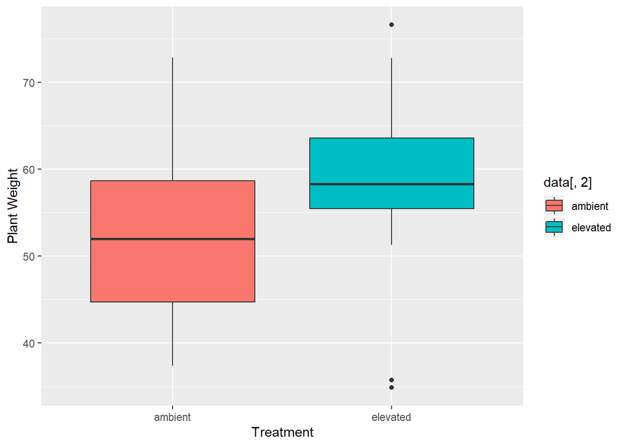

```r
graph<-graph_results(file_name=data)
```

Problem 2: Once your code is up and working, modify your program to do something else: record a new summary variable, code a new statistical analysis, or create a different set of random variables or output graph. Do not rewrite any of your existing functions. Instead, copy them, rename them, and then modify them to do new things. Once your new functions are written, add some more lines of program code, calling a mixture of your previous functions and your new functions to get te job done.

For this problem, I’m going to perform a linear regression of plant weight vs height instead of an ANOVA of plant weight by treatment. I’ll use the same global variable Data for this

```r
# Function 2 - calc_stuff   - calcuate the linear regression parameters (slope and intercept) and print them

calc_stuff2<- function(x,y) {
  LMmod<- lm(y~x)
  print(LMmod)

}

# Function 3 - summarize  - show the regression analysis table, which includes whether the slope and intercept are significantly different from 0.

summarize2<- function(x) {
  z<- summary(x)
  print(z)

}

# Function 4 - graph_results  - Plant weight vs plant height

graph_results2<- function(file_name) {
  graph1<- ggplot(data=data, aes(x=data[,3], y=data[,4], fill=data[,2]))+
  geom_point()+ geom_smooth(method = "lm") + xlab("Plant Weight (mg)") +ylab("Plant Height (cm)")
  print(graph1)
}


### String together the functions to generate results

data<- get_data(treats, n1, mean1, sd1)
LM_sum<- calc_stuff2(data$plant_wt, data$plant_ht)
```

```
##
## Call:
## lm(formula = y ~ x)
##
## Coefficients:
## (Intercept)            x
##     36.8317       0.3519
```

```r
summary_LM<- summarize2(LM_sum)
```

```
##
## Call:
## lm(formula = y ~ x)
##
## Residuals:
##      Min       1Q   Median       3Q      Max
## -23.1888  -6.1728   0.4235   6.4177  22.6815
##
## Coefficients:
##             Estimate Std. Error t value Pr(>|t|)
## (Intercept)  36.8317     9.5042   3.875 0.000408 ***
## x             0.3519     0.1751   2.009 0.051638 .
## ---
## Signif. codes:  0 '***' 0.001 '**' 0.01 '*' 0.05 '.' 0.1 ' ' 1
##
## Residual standard error: 11.09 on 38 degrees of freedom
## Multiple R-squared:  0.09605,    Adjusted R-squared:  0.07226
## F-statistic: 4.038 on 1 and 38 DF,  p-value: 0.05164
```

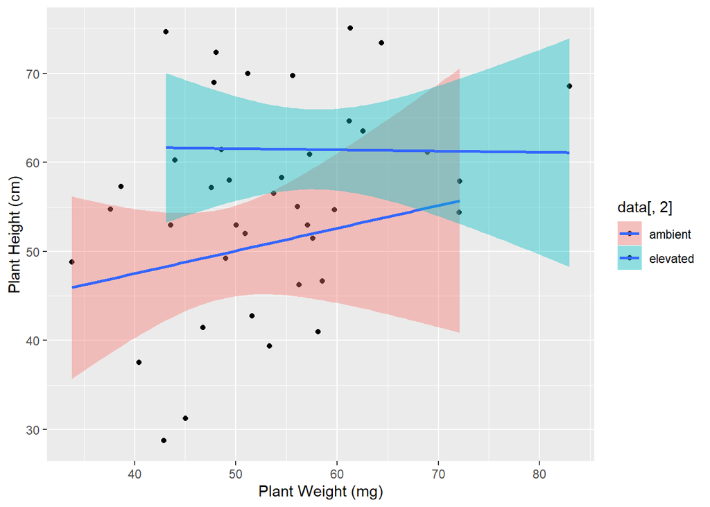

```r
graph<-graph_results2(file_name=data)
```